# Models, statistical inference, and learning

MACS 33001 University of Chicago

$$\newcommand{\E}{\mathrm{E}} \newcommand{\Var}{\mathrm{Var}} \newcommand{\Cov}{\mathrm{Cov}} \newcommand{\se}{\text{se}}$$

## Statistical inference

- Process of using data to infer the probability distribution/random variable that generated the data
- Given a sample $X_1, \ldots, X_n \sim F$, how do we infer $F$?
- All parameters? Some parameters? One parameter?

## Parametric vs. nonparametric models

- Statistical model $\xi$
- Parametric model

  $$\xi \equiv f(x; \mu, \sigma) = \frac{1}{\sigma \sqrt{2 \pi}} \exp \left[ -\frac{1}{2\sigma^2} (x - \mu)^2 \right], \quad \mu \in \Re, \sigma > 0$$
- General form

  $$\xi \equiv f(x; \theta) : \theta \in \Theta$$
- Nonparametric model
  - Infinite set $\xi$

## Parametric estimation

- One dimension
- Two dimensions

## Nonparametric density estimation

- Let $X_1, \ldots, X_n$ be independent observations from a cumulative distribution function (CDF) $F$
- Let $f = F'$ be the probability density function (PDF)
- How to estimate $f$ where $F \in \xi_{\text{ALL}}$ where $\xi_{\text{ALL}} = \{\text{all CDF's} \}$?
- Assume some smoothness on $f$
  - $f \in \xi = \xi_{\text{DENS}} \cap \xi_{\text{SOB}}$
  - $\xi_{\text{DENS}}$ is the set of all PDFs and

    $$\xi_{\text{SOB}} \equiv f: \int (f''(x))^2 dx < \infty$$

## Nonparametric density estimation

- General form

  $$g(x) = \frac{1}{nh} \sum_{i = 1}^n f(x)$$

## Infant mortality

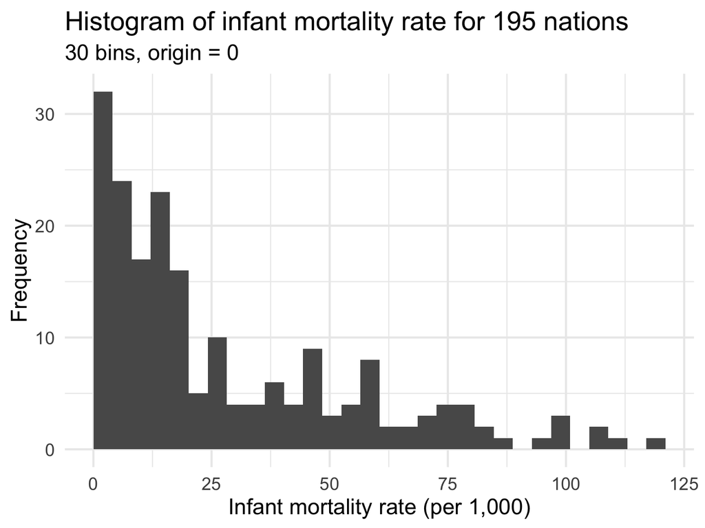

## Gaussian kernel

$$f(x) = \frac{1}{\sqrt{2 \pi}}\exp\left[-\frac{1}{2} x^2 \right]$$

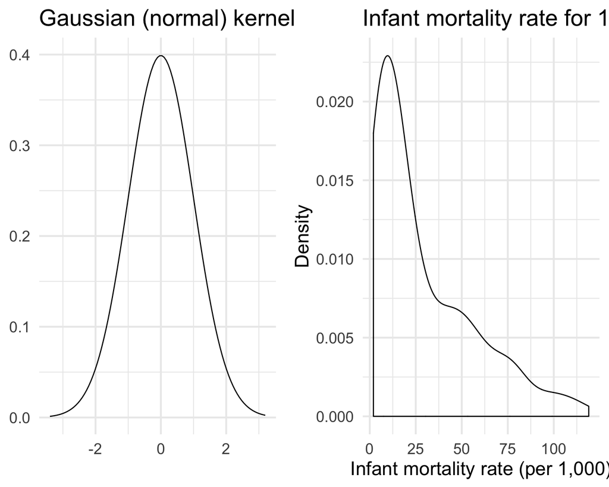

## Rectangular (uniform) kernel

$$f(x) = \frac{1}{2} \mathbf{1}_{\{ |x| \leq 1 \} }$$

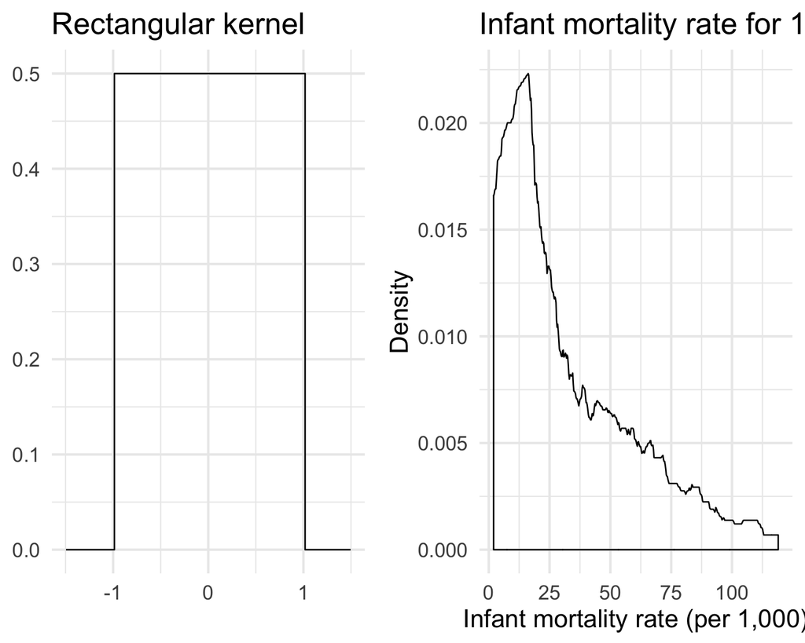

## Comparison of kernels

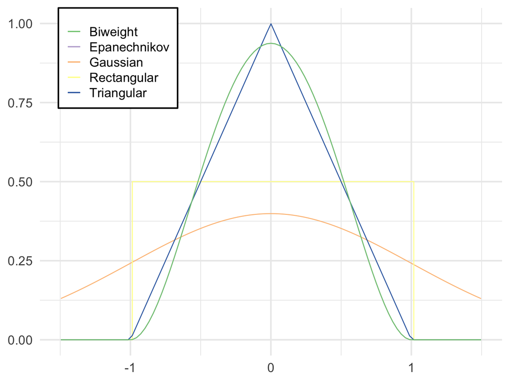

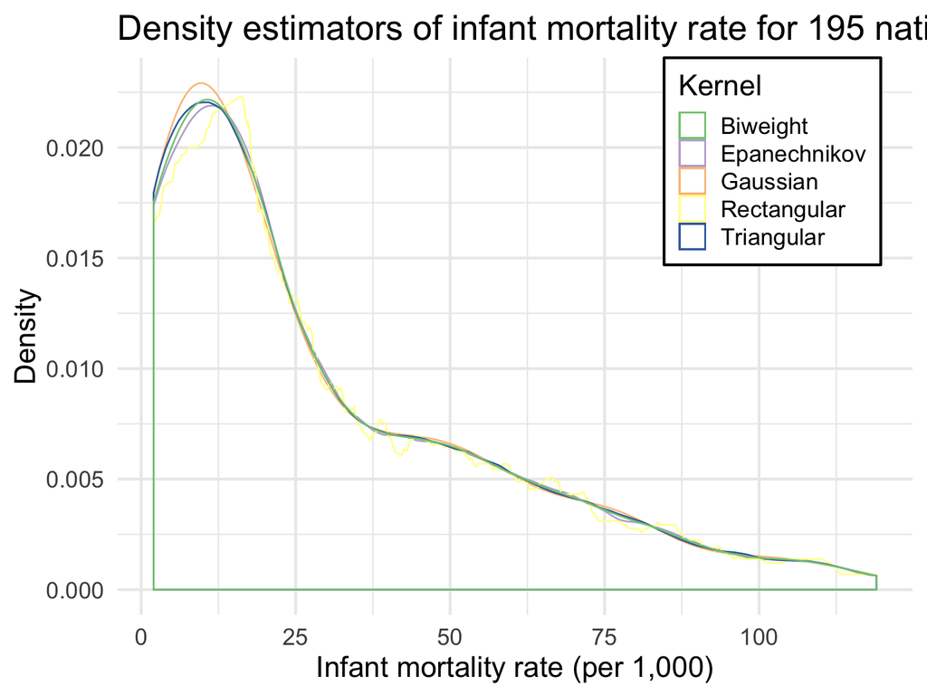

## Regression

- Suppose we observe pairs of data $(X_1, Y_1), \ldots, (X_n, Y_n)$
- $X$
- $Y$
- $r(x) = \E(Y | X = x)$
- Parametric regression
- Nonparametric regression

## Naive non-parametric regression

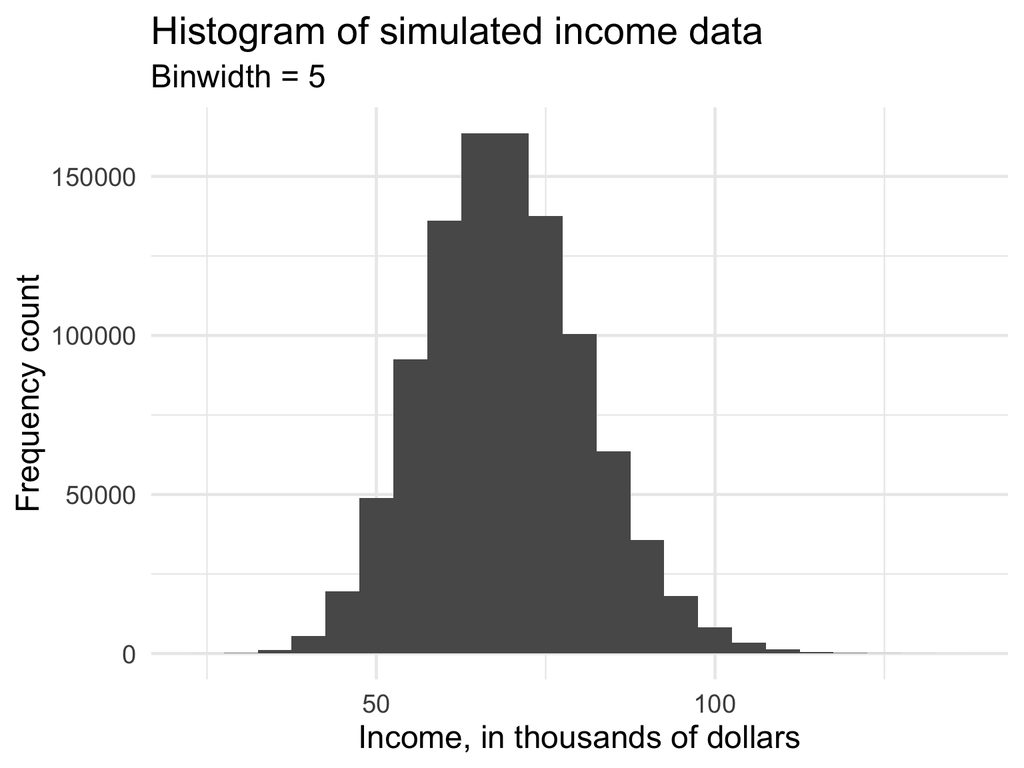

## Naive non-parametric regression

$$\mu = E(\text{Income}|\text{Education}) = f(\text{Education})$$

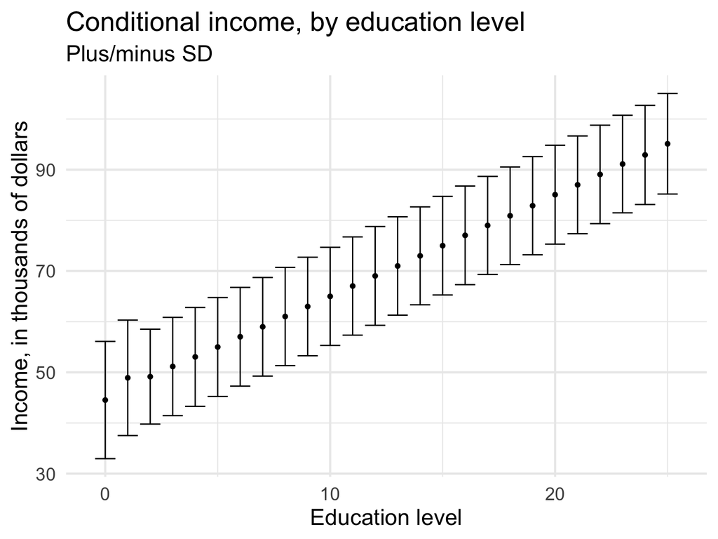

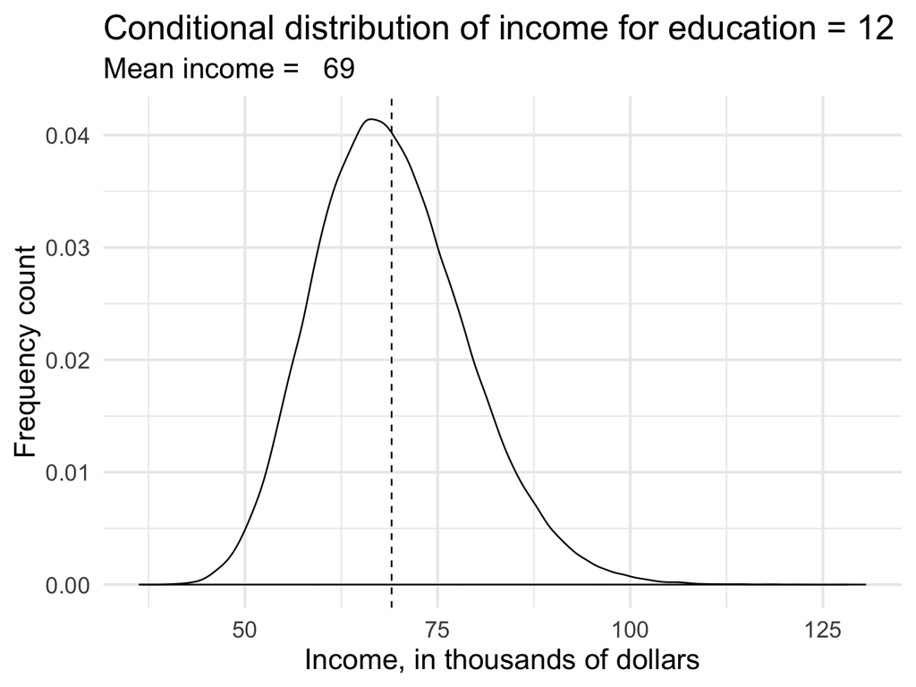

## Naive non-parametric regression

$$\mu = E(Y|x) = f(x)$$

- Binning

## Naive non-parametric regression

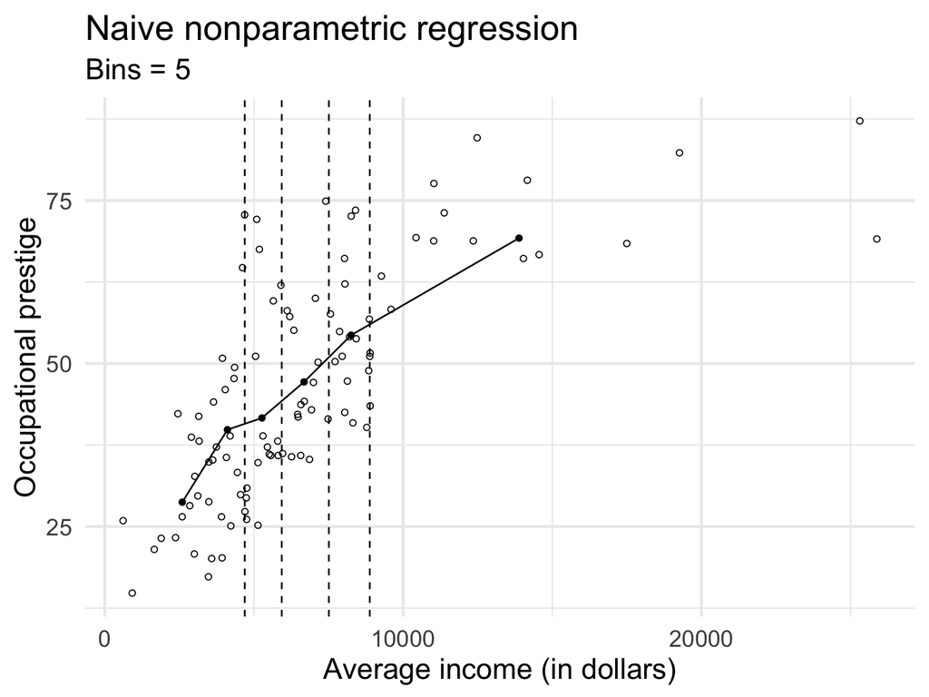

## Naive non-parametric regression

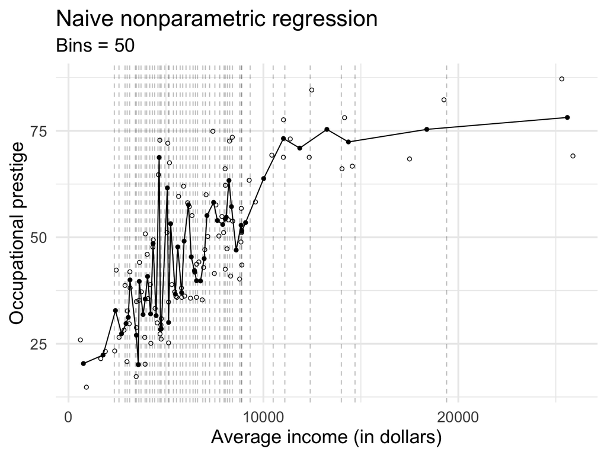

## Naive non-parametric regression

$$X_1 \in \{1, 2, \dots ,10 \}$$
$$X_2 \in \{1, 2, \dots ,10 \}$$
$$X_3 \in \{1, 2, \dots ,10 \}$$

- $10^3 = 1000$ possible combinations of the explanatory variables and $1000$ conditional expectations of $Y$ given $X$:

  $$\mu = E(Y|x_1, x_2, x_3) = f(x_1, x_2, x_3)$$

## Naive non-parametric regression

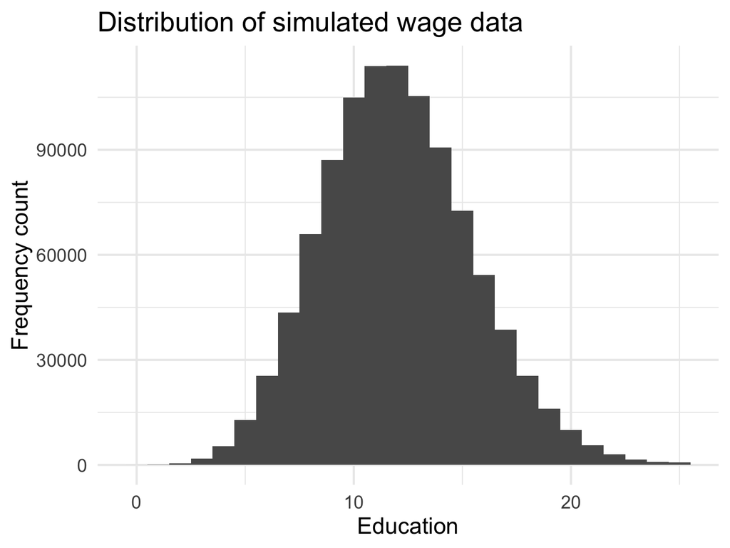

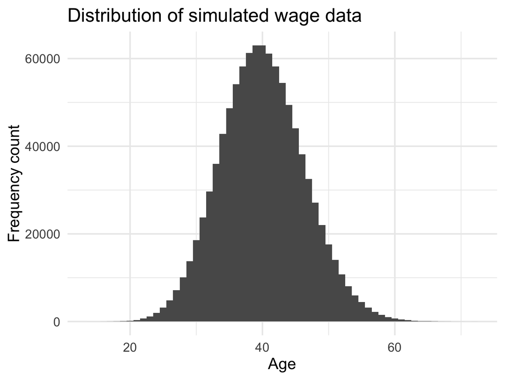

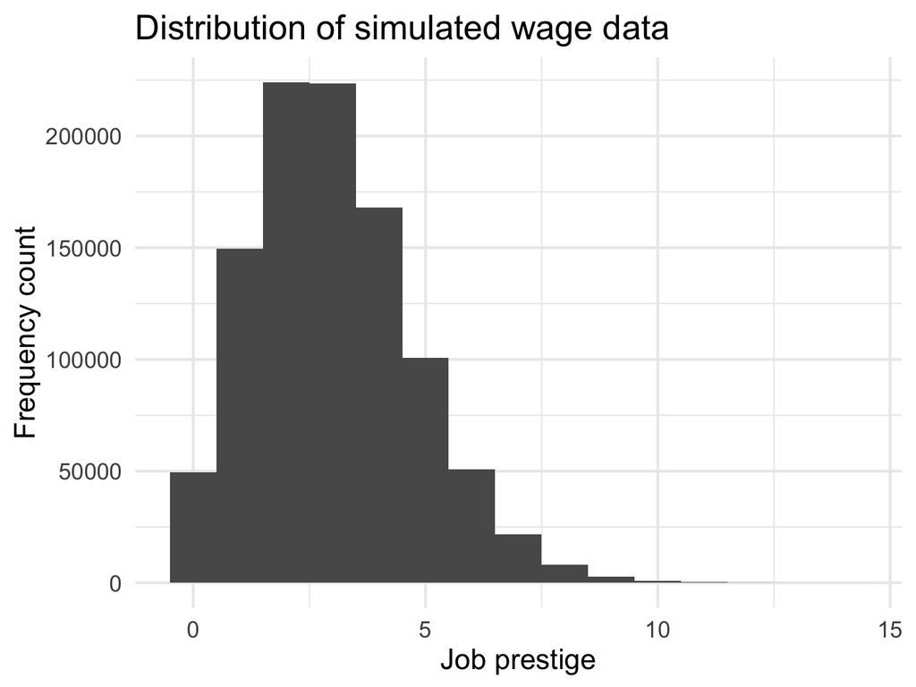

## Naive non-parametric regression

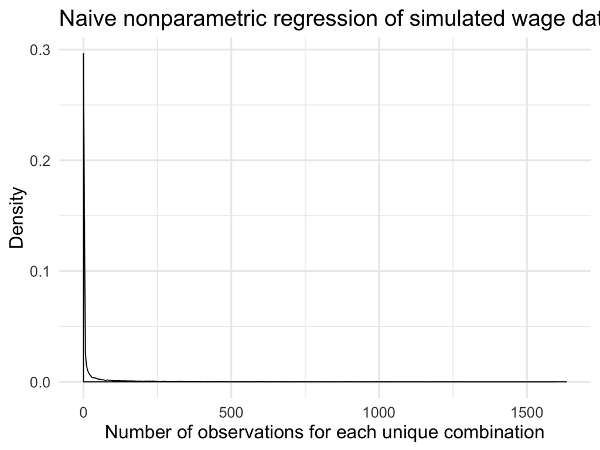

## Naive non-parametric regression

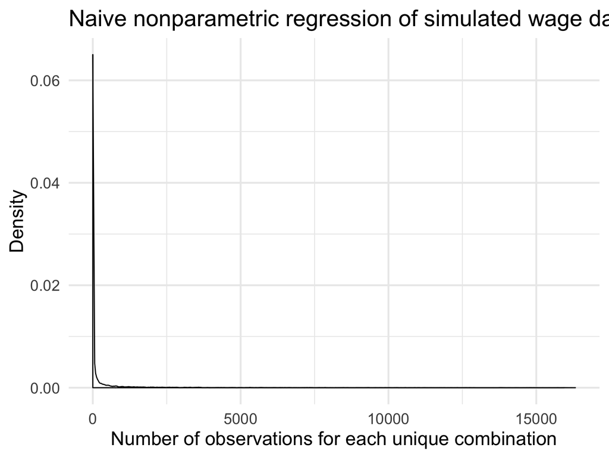

## Point estimates

- Single “best guess” of some quantity of interest
  - Parameter in a parametric model
  - CDF $F$
  - PDF $f$
  - Regression function $r$
- Point estimate of $\theta$ is $\hat{\theta}$ or $\hat{\theta}_n$
  - $\theta$ is a fixed, unknown quantity
  - $\hat{\theta}$ is a random variable
- Let $X_1, \ldots, X_n$ be $n$ IID data points from some distribution $F$. A point estimator $\hat{\theta}_n$ of a paramater $\theta$ is some function of $X_1, \ldots, X_n$:

  $$\hat{\theta}_n = g(X_1, \ldots, X_n)$$

## Properties of point estimates

- Bias
  $$\text{bias}(\hat{\theta}_n) = \E_\theta (\hat{\theta_n}) - \theta$$
- Unbiasedness
  - Is this necessary?
- Consistency

## Properties of point estimates

- Sampling distribution
- Standard error

  $$\se = \se(\hat{\theta}_n) = \sqrt{\Var (\hat{\theta}_n)}$$
  - Depends on the unknown $F$
  - Usually estimated from the data ($\widehat{\se}$)
- Mean squared error

  $$\begin{align}
  \text{MSE} &= \E_\theta (\hat{\theta}_n - \theta)^2 \\
  &= \text{bias}^2(\hat{\theta}_n) + \Var_\theta (\hat{\theta}_n)
  \end{align}$$

## Properties of point estimates

- Estimators are approximately Normally distributed

  $$\frac{\hat{\theta}_n - \theta}{\se} \leadsto N(0,1)$$

## Example: Bernoulli distributed random variable

- Let $X_1, \ldots, X_n ~ \text{Bernoulli}(\pi)$
- Let $\hat{\pi}_n = \frac{1}{n} \sum_{i=1}^n X_i$. Then

  $$\E(\hat{\pi}_n) = \frac{1}{n} \sum_{i=1}^n \E(X_i) = \pi$$

  so $\hat{\pi}_n$ is unbiased
- Standard error is

  $$\se = \sqrt{\Var (\hat{\pi}_n)} = \sqrt{\frac{\pi (1 - \pi)}{n}}$$

  $$\widehat{\se} = \sqrt{\frac{\hat{\pi} (1 - \hat{\pi})}{n}}$$
- $\E_\pi (\hat{\pi}_n) = \pi$ so $\text{bias} = \pi - \pi = 0$

  $$\begin{align}
  \text{bias}(\hat{\pi}_n) &= \E_\pi (\hat{\pi}) - \pi \\
  &= \pi - \pi \\
  &= 0
  \end{align}$$
- Consistency
  $$\se = \sqrt{\frac{\pi (1 - \pi)}{n}} \rightarrow 0$$

## Confidence sets

- $1 - \alpha$ confidence interval for $\theta$ is an interval $C_n = (a,b)$
  - $a = a(X_1, \ldots, X_n)$
  - $b = b(X_1, \ldots, X_n)$

    $$\Pr_{\theta} (\theta \in C_n) \geq 1 - \alpha, \quad \forall \theta \in \Theta$$
- $(a,b)$ traps $\theta$ with probability $1- \alpha$

## Caution interpreting confidence intervals

- $C_n$ is random and $\theta$ is fixed
- 95% confidence intervals corresponding to $\alpha = 0.05$
- A confidence interval is not a probability statement about $\theta$

## Proper interpretation

> On day 1, you collect data and construct a 95% confidence interval for a parameter $\theta_1$. On day 2, you collect new data and construct a 95% confidence interval for a parameter $\theta_2$. You continue this way constructing confidence intervals for a sequence of unrelated parameters $\theta_1, \theta_2, \ldots$. Then 95% of your intervals will trap the true parameter value.

## Constructing confidence intervals

- Approximately Normal - use the Normal distribution
- Suppose that $\hat{\theta}_n \approx N(\theta, \widehat{\se}^2)$
- Let $\Phi$ be the CDF of a standard Normal distribution

  $$z_{\frac{\alpha}{2}} = \Phi^{-1} \left(1 - \frac{\alpha}{2} \right)$$

  $$\Pr (Z > \frac{\alpha}{2}) = \frac{\alpha}{2}$$

  $$\Pr (-z_{\frac{\alpha}{2}} \leq Z \leq z_{\frac{\alpha}{2}}) = 1 - \alpha$$

  where $Z \sim N(0,1)$
- Let

  $$C_n = (\hat{\theta}_n - z_{\frac{\alpha}{2}} \widehat{\se}, \hat{\theta}_n + z_{\frac{\alpha}{2}} \widehat{\se})$$
- Then

  $$\begin{align}
  \Pr_\theta (\theta \in C_n) &= \Pr_\theta (\hat{\theta}_n - z_{\frac{\alpha}{2}} \widehat{\se} < \theta < \hat{\theta}_n + z_{\frac{\alpha}{2}} \widehat{\se}) \\
  &= \Pr_\theta (- z_{\frac{\alpha}{2}} < \frac{\hat{\theta}_n - \theta}{\widehat{\se}} < z_{\frac{\alpha}{2}}) \\
  &\rightarrow \Pr ( - z_{\frac{\alpha}{2}} < Z < z_{\frac{\alpha}{2}}) \\
  &= 1 - \alpha
  \end{align}$$
- $\alpha = 0.05$ and $z_{\frac{\alpha}{2}} = 1.96 \approx 2$

## Actual vs. approximate confidence intervals

- Let $X_1, \ldots, X_n \sim \text{Bernoulli}(\pi)$ and let $\hat{\pi}_n = \frac{1}{n} \sum_{i=1}^n X_i$
- Let $C_n = (\hat{\pi}_n - \epsilon_n, \hat{\pi}_n + \epsilon_n)$ where $\epsilon_n^2 = \frac{\log(\frac{2}{\alpha})}{2n}$
- From this,

  $$\Pr (\pi \in C_n \geq 1 - \alpha)$$
- $C_n$ is a precise $1 - \alpha$ confidence interval
- Approximate confidence interval

  $$\begin{align}
  \Var (\hat{\pi}_n) &= \frac{1}{n^2} \sum_{i=1}^n \Var(X_i) \\
  &= \frac{1}{n^2} \sum_{i=1}^n \pi(1 - \pi) \\
  &= \frac{1}{n^2} n\pi(1 - \pi) \\
  &= \frac{\pi(1 - \pi)}{n} \\
  \se &= \sqrt{\frac{\pi(1 - \pi)}{n}} \\
  \widehat{\se} &= \sqrt{\frac{\hat{\pi}(1 - \hat{\pi})}{n}}
  \end{align}$$

  $$\hat{\pi}_n \pm z_{\frac{\alpha}{2}} \widehat{\se} = \hat{\pi}_n \pm z_{\frac{\alpha}{2}} \sqrt{\frac{\hat{\pi}(1 - \hat{\pi})}{n}}$$

## Hypothesis testing

- Default theory
- Null vs. alternative hypothesis
- Sufficient evidence to reject the null hypothesis?
- Let

  $$X_1, \ldots, X_n \sim \text{Bernoulli}(\pi)$$
- Is it a fair coin?
  - $H_0: \pi = 0.5$
  - $H_1: \pi \neq 0.5$
  - Reasonable to reject $H_0$ if

    $$T = | \hat{\pi}_n - 0.5|$$
    is large